# sample

Kim

2019 6 10

## R Markdown

### 연습문제 1.

#### mpg 데이터의 cty(도시 연비)와 hwy(고속도로 연비) 간에 어떤 관계가 있는지 알아보려고 합니다. x축은 cty, y축은 hwy로 된 산점도를 만들어 보세요.

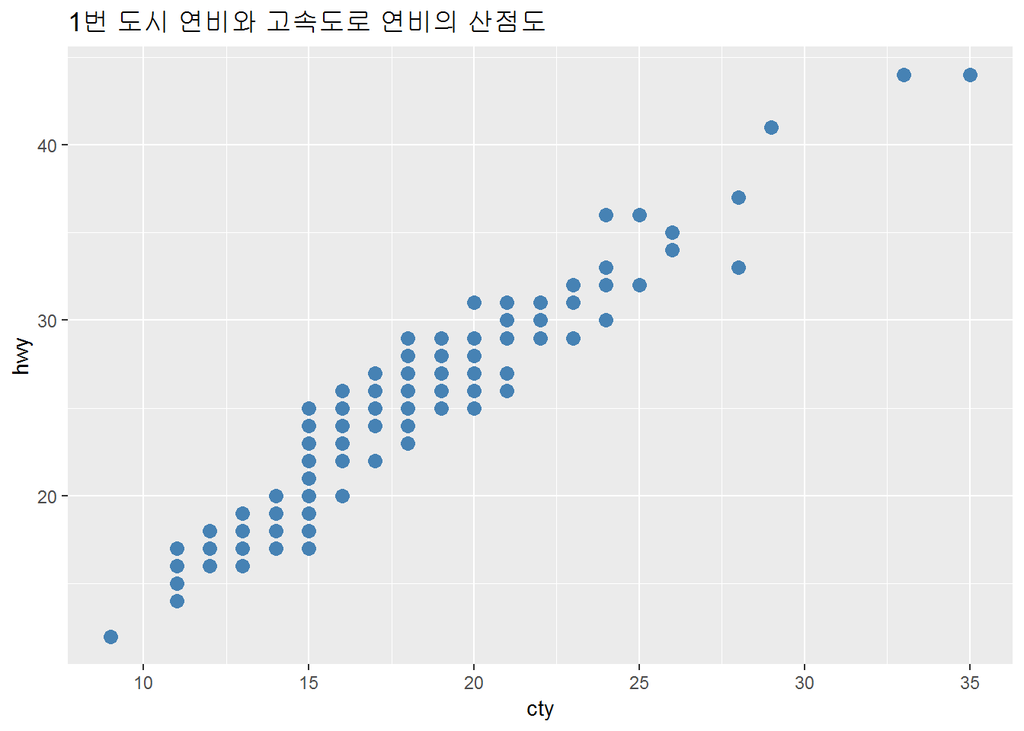

```r
library(ggplot2)
library(dplyr)
### 연습문제 1
ggplot(mpg,aes(x=cty,y=hwy)) +
  geom_point(color='steel blue',size=3)+
  ggtitle('1번 도시 연비와 고속도로 연비의 산점도')
```

### 연습문제 2.  
#### 미국 지역별 인구통계 정보를 담은 ggplot2 패키지의 midwest 데이터를 이용해서 전체 인구와 아시아인 인구 간에 어떤 관계가 있는지 알아보려고 합니다. x축은 poptotal(전체 인구), y축은 popasian(아시아인 인구)으로 된 산점도를 만들어 보세요. 전체 인구는 50만 명 이하, 아시아인 인구는 1만 명 이하인 지역만 산점도에 표시되게 설정하세요.

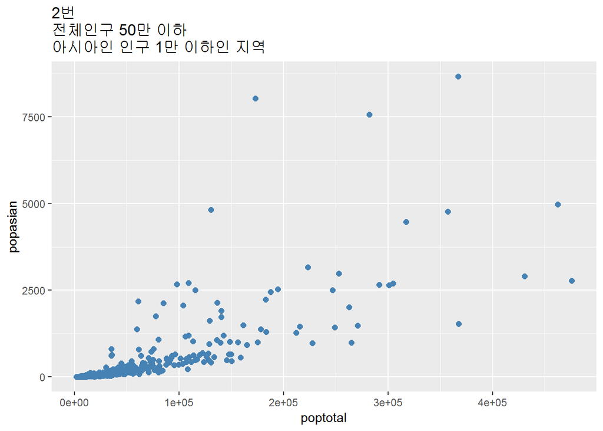

```r
### 연습문제 2
midwest2 <- midwest %>% filter(poptotal<=500000,popasian<=10000)
ggplot(midwest2,aes(x=poptotal,y=popasian))+
  geom_point(color='steel blue',size=2)+
  ggtitle('2번 \n전체인구 50만 이하 \n아시아인 인구 1만 이하인 지역')
```

### 연습문제 3.  
#### 어떤 회사에서 생산한 “suv” 차종의 도시 연비가 높은지 알아보려고 합니다. “suv” 차종을 대상으로 평균 cty(도시 연비)가 가장 높은 회사 다섯 곳을 막대 그래프로 표현해 보세요. 막대는 연비가 높은 순으로 정렬하세요.

```r
### 연습문제 3
suv <- mpg %>% filter(class=='suv') %>%
  select(manufacturer,cty,class) %>%
  group_by(manufacturer) %>%
  summarise_each(funs(mean),cty) %>%
  arrange(desc(cty)) %>%
  head(5)
```

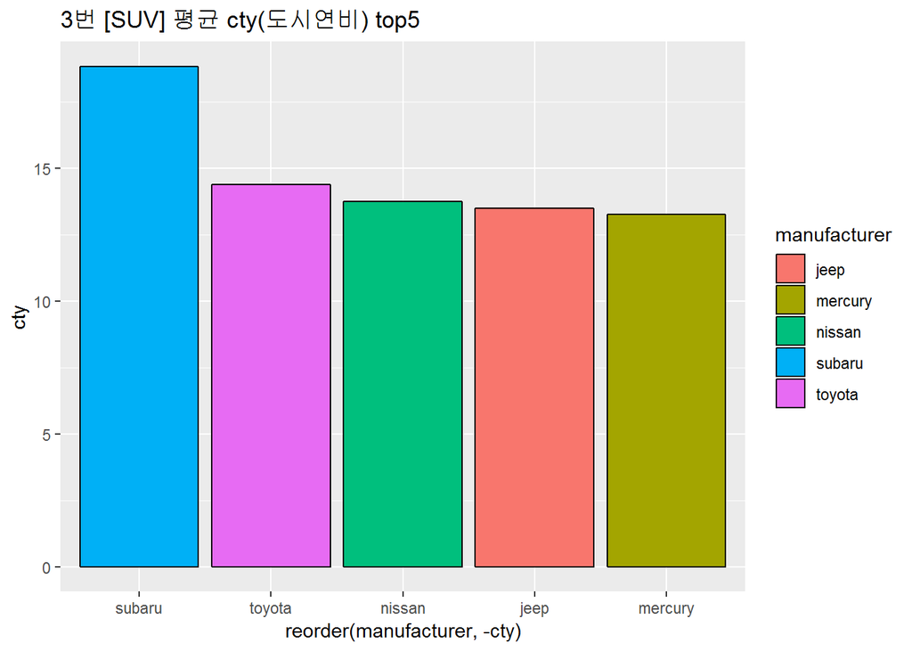

```r
ggplot(suv,aes(x=reorder(manufacturer,-cty),y=cty,
               fill=manufacturer)) +
  geom_bar(stat="identity", color="black")+
  ggtitle('3번 [SUV] 평균 cty(도시연비) top5 ')
```

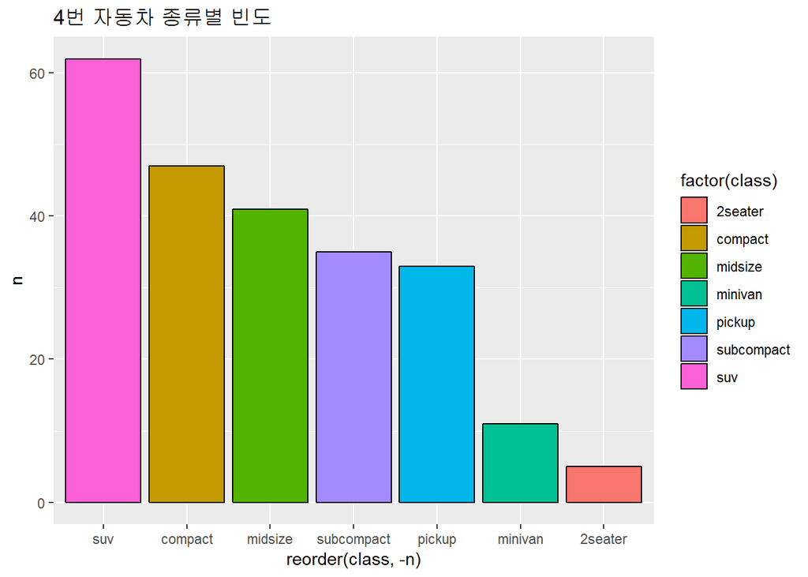

```r
### 연습문제 4
class<-mpg %>%
  select(class) %>%
  group_by(class) %>%
  summarise(n=n())

ggplot(class,aes(x=reorder(class,-n),y=n,fill=factor(class)))+
  geom_bar(stat="identity",color="black")+
  ggtitle('4번 자동차 종류별 빈도')
```

### 연습문제 5.  
#### economics 데이터를 이용해서 psavert(개인 저축률)가 시간에 따라서 어떻게 변해왔는지 알아보려고 합니다. 시간에 따른 개인 저축률의 변화를 나타낸 시계열 그래프를 만들어 보세요.

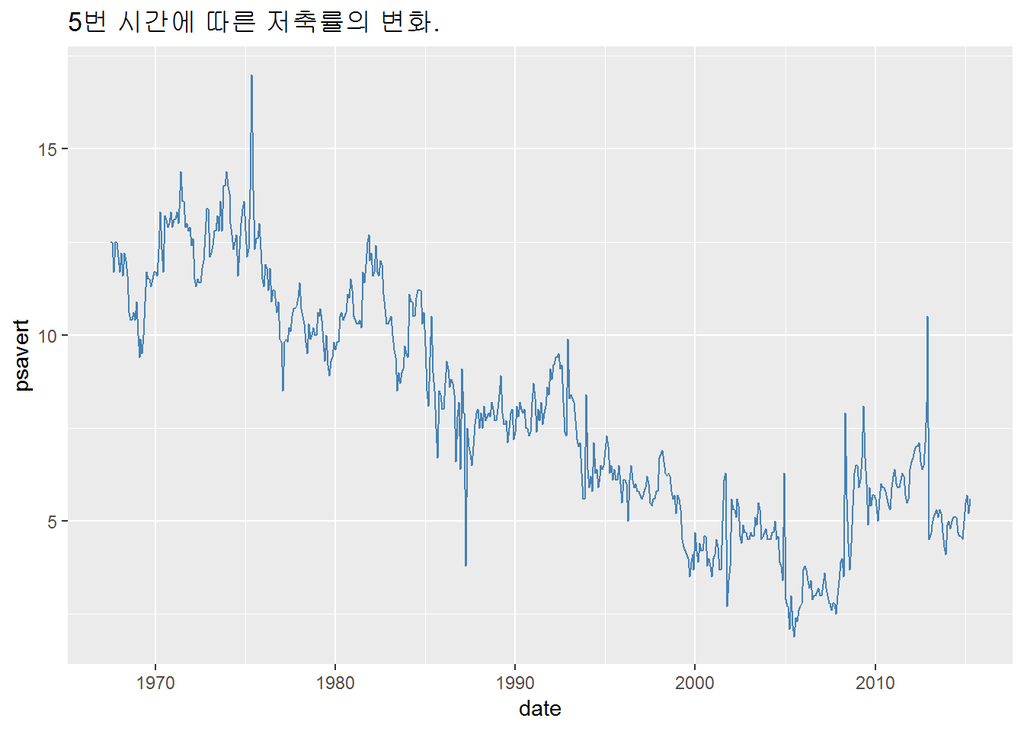

```r
### 연습문제 5
ggplot(economics,aes(x=date,y=psavert))+
  geom_line(color="steel blue")+
  ggtitle('5번 시간에 따른 저축률의 변화.')
```

### 연습문제 6.  
#### class(자동차 종류)가 “compact”, “subcompact”, “suv”인 자동차의 cty(도시 연비)가 어떻게 다른지 비교해보려고 합니다. 세 차종의 cty를 나타낸 상자 그림을 만들어보세요.

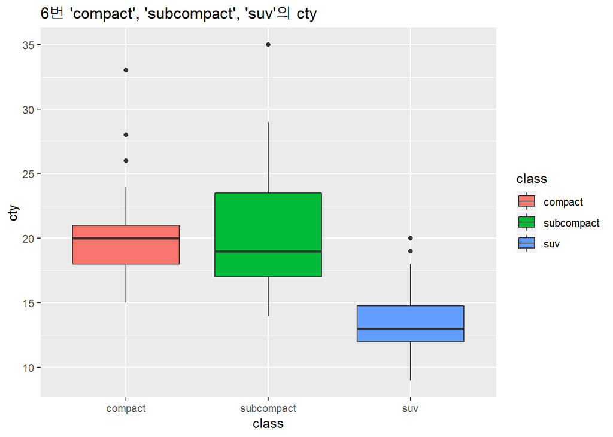

```r
### 연습문제 6
a <- mpg %>%
  filter(class %in% c('compact','subcompact','suv')) %>%
  select(class,cty)

ggplot(a, aes(x=class,y=cty ,group=class,fill=class))+
  geom_boxplot() +
  ggtitle("6번 'compact', 'subcompact', 'suv'의 cty")
```

```r
### 연습문제 7
diamonds
```

```
## # A tibble: 53,940 x 10
##    carat cut       color clarity depth table price     x     y     z
##    <dbl> <ord>     <ord> <ord>   <dbl> <dbl> <int> <dbl> <dbl> <dbl>
##  1 0.23  Ideal     E     SI2      61.5    55   326  3.95  3.98  2.43
##  2 0.21  Premium   E     SI1      59.8    61   326  3.89  3.84  2.31
##  3 0.23  Good      E     VS1      56.9    65   327  4.05  4.07  2.31
##  4 0.290 Premium   I     VS2      62.4    58   334  4.2   4.23  2.63
##  5 0.31  Good      J     SI2      63.3    58   335  4.34  4.35  2.75
##  6 0.24  Very Good J     VVS2     62.8    57   336  3.94  3.96  2.48
##  7 0.24  Very Good I     VVS1     62.3    57   336  3.95  3.98  2.47
##  8 0.26  Very Good H     SI1      61.9    55   337  4.07  4.11  2.53
##  9 0.22  Fair      E     VS2      65.1    61   337  3.87  3.78  2.49
## 10 0.23  Very Good H     VS1      59.4    61   338  4     4.05  2.39
## # ... with 53,930 more rows
```

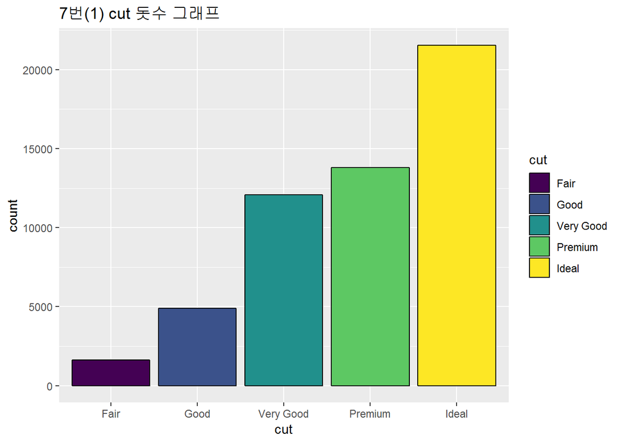

```r
# 1) cut의 도수가.n()을....말한다..?
ggplot(diamonds,aes(x=cut,fill=cut)) +
  geom_bar(color="black")+
  ggtitle("7번(1) cut 돗수 그래프")
```

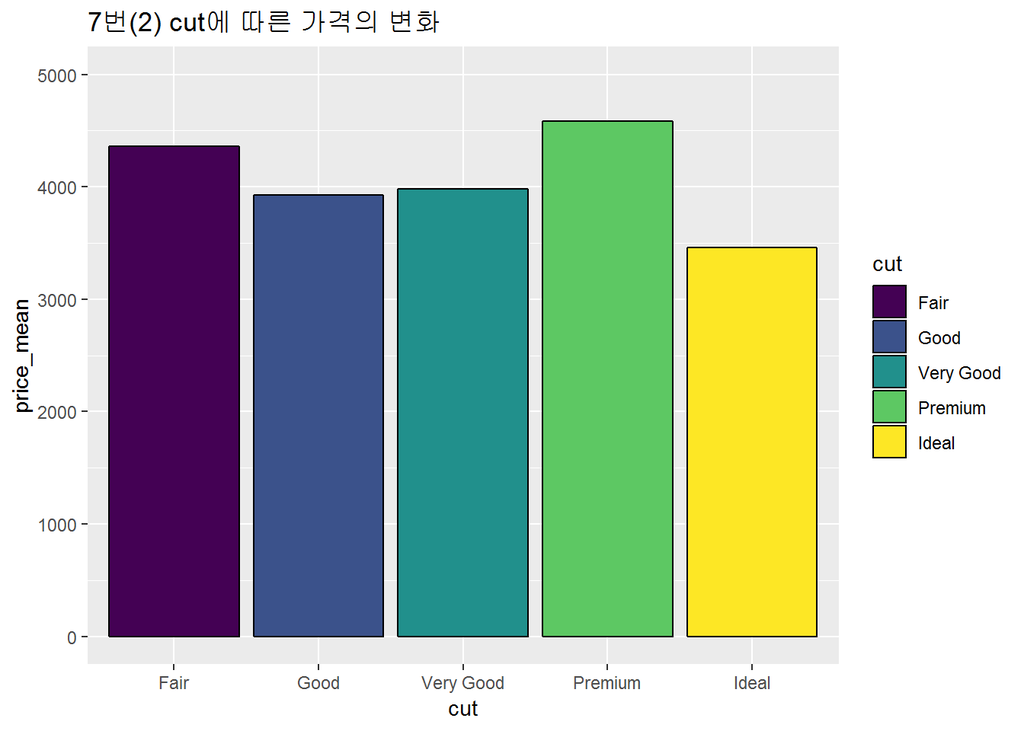

```r
# 2) cut에 따른 가격의 변화를 보여주는 그래프
cut <- diamonds %>%
  select(cut,price) %>%
  group_by(cut) %>%
  summarise(price_mean=mean(price,na.rm=T))

ggplot(cut,aes(x=cut,y=price_mean,fill=cut))+
  geom_bar(stat="identity",color="black")+
  ggtitle("7번(2) cut에 따른 가격의 변화 ")+
  ylim(0,5000)
```

```r
# 3) 3번문제는 cut과 color를 따로 해서 grid로 합침..ㄷㄷ..

#ggplot(diamonds, aes(x=price))+geom)histogram(bins=10)+facet_wrap(-cut,)
#grid.arrange(gcut,gcolor)
```

*글자체 Italic*  
**글자체 Bold**  
*Bold Italic*  
취소선  
문장 맨뒤에 스페이스가 2개 있어도 줄바뀐다. 하이퍼 링크 - 이젠

#### 순서없는 목록(Unordered List)

- 수박
- 참외
- 토마토
- 토마토 (*, +, - 동일한 효과)
  - 완숙 토마토(문장 시작에 탭을 두번 입력)
  - 방울 토마토

#### 순서있는 목록(ordered List)

1. R
2. Python
3. Java
1. Eclipse
2. Tomcat